# Phylogenetic relationships & tree structure

Will Harvey

January 27 2025

```r
# load the package into R
library(toolkitSeqTree)

# load other useful packages
library(ggtree)
library(ggplot2)
library(dplyr)
```

## Identifying node ancestors and descendants

First we read a tree into R and “fortify” using `ggtree::fortify()` the tree object which produces a data frame with one row representing each tree node.

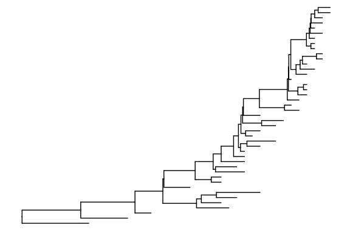

```r
tree <- treeio::read.beast('../inst/extdata/h1n1_ref_viruses.trees')
tree_dat <- fortify(tree)
ggtree(tree)
```

```r
head(tree_dat)
```

```
#> # A tibble: 6 × 10
#>   parent  node branch.length label        Control isTip     x     y branch angle
#>    <int> <int>         <dbl> <chr>        <chr>   <lgl> <dbl> <dbl>  <dbl> <dbl>
#> 1     45     1          6.03 H1N1_A_CHIL… 1       TRUE   13.6     2   10.5  16.7
#> 2     48     2          4.16 H1N1_A_JOHA… 2       TRUE   26.6     4   24.5  33.5
#> 3     49     3          2.54 H1N1_A_BAYE… 3       TRUE   25.6     5   24.3  41.9
#> 4     50     4          2.61 H1N1_A_WELL… 4       TRUE   27.6     6   26.3  50.2
#> 5     50     5          5.61 H1N1_A_CHIL… 5       TRUE   30.6     7   27.8  58.6
#> 6     53     6          1.27 H1N1_A_BEIJ… 6       TRUE   25.6     9   24.9  75.3
```

The relationships between nodes of the phylogeny are contained in `tree_dat` columns `tree_dat$node` and `tree_dat$parent`. For a bifurcating tree, each internal node of the phylogeny is the parent of two nodes.

The exception to this rule is that the root of the phylogeny is the parent of three nodes including itself, so for the root of the phylogeny, `tree_dat$node == tree_dat$parent`:

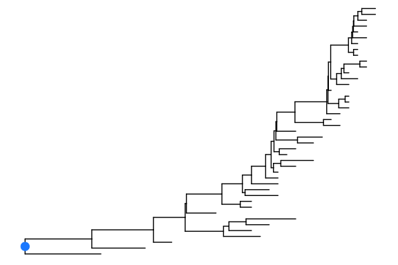

```r
# plot tree with root highlighted
ggtree(tree) +
  geom_point(data = subset(tree_dat, node == parent),
             col = 'dodgerblue', size = 4)
```

### Descendants of a given node

For various exercises, it can be useful to use `node_descendants()` to identify all nodes (red diamonds) that are descended from a particular internal node (blue circle) of the phylogeny.

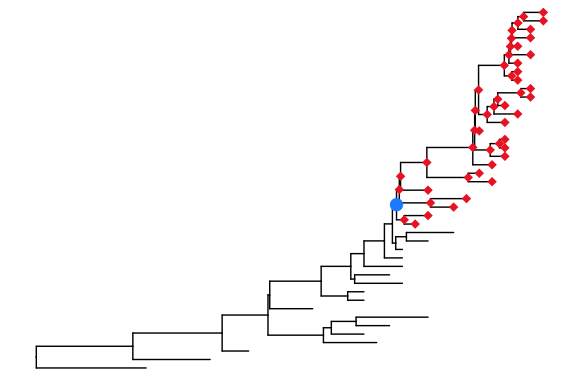

```r
# This example uses node 60 as a randomly chosen internal node
target_node <- 60
descendants <- node_descendants(tree_dat, node_id = target_node)

# plot tree with target node highlighted as blue circle
# and descendants of target node as red diamonds
ggtree(tree) +
  geom_point(data = subset(tree_dat, node == target_node),
             col = 'dodgerblue', size = 4) +
  geom_point(data = subset(tree_dat, node %in% descendants),
             col = 'firebrick2', shape = 18, size = 3)
```

This function also allows the option to only return descendants nodes that are external tip nodes, using `tips_only = TRUE`.

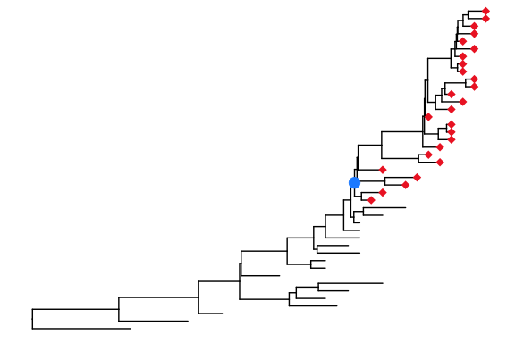

```r
# This example uses node 60 as a randomly chosen internal node
target_node <- 60
descendants <- node_descendants(tree_dat, node_id = target_node,
                                tips_only = TRUE)

# plot tree with target node highlighted as blue circle
# and descendants of target node as red diamonds
ggtree(tree) +
  geom_point(data = subset(tree_dat, node == target_node),
             col = 'dodgerblue', size = 4) +
  geom_point(data = subset(tree_dat, node %in% descendants),
             col = 'firebrick2', shape = 18, size = 3)
```

### Ancestors of a given node.

Similarly, it can be useful to identify ancestors of a node using `node_ancestors()`. Unlike `node_descendants()`, this function can be run using a terminal node (or tip) in addition to internal nodes. For this example, node 60 will be used again as the node of interest. The results returned from `node_ancestors()` should form a path between the node 60 and the root of the phylogeny.

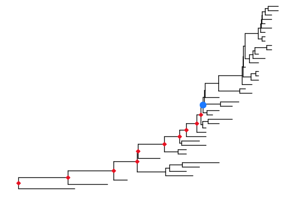

```r
target_node <- 60
ancestors <- node_ancestors(tree_dat, node_id = target_node)

ggtree(tree) +
  geom_point(data = subset(tree_dat, node == target_node),
             col = 'dodgerblue', size = 4) +
  geom_point(data = subset(tree_dat, node %in% ancestors),
             col = 'firebrick2', shape = 18, size = 3)
```

One feature of `node_ancestors()` is that ancestral nodes are identified from the direct parent of the target node back through the tree to the route. Indexing, e.g. `ancestors[1]`

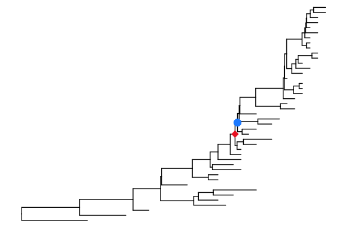

```r
# Highlight first node in 'ancestors' as red diamond
ggtree(tree) +
  geom_point(data = subset(tree_dat, node == target_node),
             col = 'dodgerblue', size = 4) +
  geom_point(data = subset(tree_dat, node %in% ancestors[1]),
             col = 'firebrick2', shape = 18, size = 4)
```

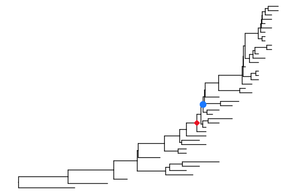

```r
# Highlight second node in 'ancestors' as red diamond
ggtree(tree) +
  geom_point(data = subset(tree_dat, node == target_node),
             col = 'dodgerblue', size = 4) +
  geom_point(data = subset(tree_dat, node %in% ancestors[2]),
             col = 'firebrick2', shape = 18, size = 4)
```

This feature of `node_ancestors()` makes it useful in identifying the node representing the most recent common ancestor in the phylogeny.

### MRCA of two taxa or nodes.

The function `nodes_relationship()` will take two taxa labels (or alternatively two node numbers - which can include internal nodes) and with the argument `relationship = 'mrca'` will identify the node representing their most recent common ancestor (MRCA).

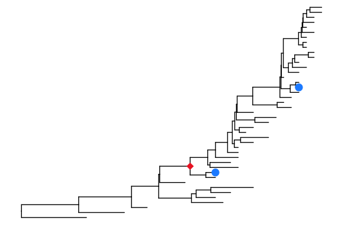

```r
# Pair of taxa of interest are selected and function
taxa_interested <- c('H1N1_A_WUHAN_371_1995',
                     'H1N1_A_FUKUSHIMA_141_2006')
taxa_mrca <- nodes_relationship(tree_dat, taxa = taxa_interested,
                                relationship = 'mrca')

# Highlight taxa_interested as blue circles and MRCA as red diamond
ggtree(tree) +
  geom_point(data = subset(tree_dat, label %in% taxa_interested),
             col = 'dodgerblue', size = 4) +
  geom_point(data = subset(tree_dat, node %in% taxa_mrca),
             col = 'firebrick2', shape = 18, size = 4)
```

### Path between nodes

It may be useful for some analyses to define a path between two nodes (probably between two tips in most cases). The nodes that form this path lie between the two nodes and their MRCA.

This set of nodes (it may be more intuitive to consider the branches) forming this path is identified from the ancestors of the two nodes/taxa identified using `node_ancestors()`. The set forming the path is the set of nodes/branches which are in either of the sets of ancestors, but not their intersection (known as the symmetric difference or disjunctive union of the two sets).

It will usually make sense to complete the path by supplementing this set of nodes with the node/branch connecting the target nodes using the `node_ancestors()` argument `keep_target_node = TRUE`.

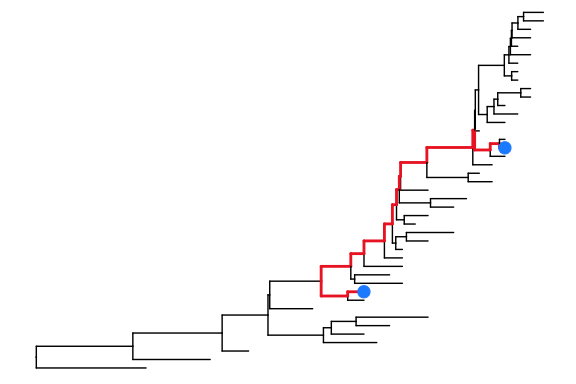

```r
# ID ancestors of two randomly chosen taxa
taxa_interested <- c('H1N1_A_WUHAN_371_1995',
                     'H1N1_A_FUKUSHIMA_141_2006')
ancestors_1 <- node_ancestors(tree_dat, taxa_interested[1],
                              keep_target_node = TRUE)
ancestors_2 <- node_ancestors(tree_dat, taxa_interested[2],
                              keep_target_node = TRUE)

# Nodes in the path between two taxa are identified as the difference
# between the union and the intersect of the two sets of ancestors
path_nodes <- setdiff(union(ancestors_1, ancestors_2),
                      intersect(ancestors_1, ancestors_2))

# Highlight path branches as thicker and red
ggtree(tree, aes(color = node %in% path_nodes,
                 size = node %in% path_nodes)) +
  scale_color_manual(values = c('black', 'firebrick2'), guide = 'none') +
  scale_size_manual(values = c(0.5, 1), guide = 'none') +
  geom_point(data = subset(tree_dat, label %in% taxa_interested),
             col = 'dodgerblue', size = 4)
```

Alternatively, the path between two taxa can be identified using `nodes_relationship()` with the relationship argument set to path (`relationship = 'path'`), which is also the default option.

```r
path_nodes
```

```
#>  [1]  7 53 14 68 67 66 65 64 63 62 60 57 56 55 54
```

```r
nodes_relationship(tree_dat, taxa = taxa_interested,
                   relationship = 'path')
```

```
#>  [1]  7 53 14 68 67 66 65 64 63 62 60 57 56 55 54
```

### Shared evolutionary history

Given the two sets of ancestor nodes for two taxa (or nodes), the symmetric difference or disjunctive union of the two sets gives the path between the two taxa through the tree. Alternatively, the intersect of the two sets of ancestors represents the shared evolutionary history of the two taxa. This set can be identified using `nodes_relationship()` with the `relationship = 'shared'`.

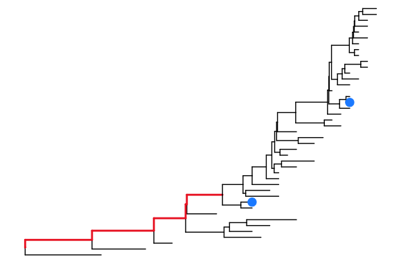

```r
taxa_interested <- c('H1N1_A_WUHAN_371_1995',
                     'H1N1_A_FUKUSHIMA_141_2006')

shared_nodes <- nodes_relationship(tree_dat, taxa = taxa_interested,
                                   relationship = 'shared')

# Highlight branches in shared evolutionary history as thicker and red
ggtree(tree, aes(color = node %in% shared_nodes,
                 size = node %in% shared_nodes)) +
  scale_color_manual(values = c('black', 'firebrick2'), guide = 'none') +
  scale_size_manual(values = c(0.5, 1), guide = 'none') +
  geom_point(data = subset(tree_dat, label %in% taxa_interested),
             col = 'dodgerblue', size = 4)
```

### MRCA of a set of tips

The above function can be used to find the node representing the MRCA of two nodes. If the MRCA of a larger set of tips is required, `set_mrca.R` can be used.

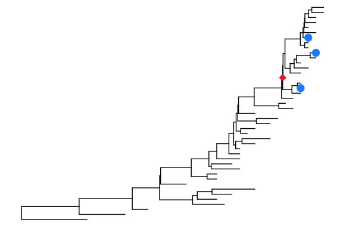

```r
# Pair of taxa of interest are selected and function
taxa_interested <- c('H1N1_A_NETHERLANDS_345_2007',
                     'H1N1_A_FUKUSHIMA_141_2006',
                     'H1N1_A_HONGKONG_1870_2008')
taxa_mrca <- set_mrca(tree_dat,
                      tip_set = tree_dat$node[tree_dat$label %in% taxa_interested])

# Highlight taxa_interested as blue circles and MRCA as red diamond
ggtree(tree) +
  geom_point(data = subset(tree_dat, label %in% taxa_interested),
             col = 'dodgerblue', size = 4) +
  geom_point(data = subset(tree_dat, node %in% taxa_mrca),
             col = 'firebrick2', shape = 18, size = 4)
```

## Creating variables

In an analysis exploring variation in some trait associated with a property of each taxa or perhaps measurements that reflect the similarity of taxa. To explore variation in a trait measured per taxa, it may be sensible to use variables representing whether each node/branch exists in the evolutionary history of that taxa (i.e. is the node/branch identified as an ancestor using `node_ancestors()`, or not). To explore variation in a trait measured between pairs of taxa, it may be sensible to to use variables representing whether each node/branch separates the pair in a path drawn through the tree along branches of the phylogeny. Variables of this nature can be classified using `nodes_relationship()` with `relationship = 'path'`.

### Ancestor variables

Logical variable for each node/branch and whether or not it is an ancestor of each taxa. This generates a set of variables with one observation per taxon/tip.

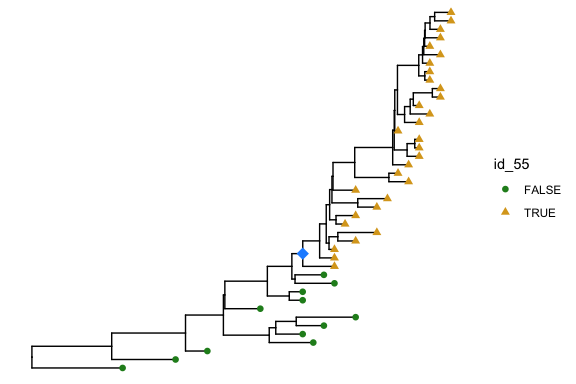

```r
# merge output from generate_branch_vars() with tree_dat
dat <- generate_branch_vars(tree_dat, variable_type = 'identity')
tree_dat <- left_join(tree_dat, dat, by = 'label')

# Highlight node 55 as blue diamond & have tip points vary by the variable 'id_55'
ggtree(tree) +
  geom_point(data = subset(tree_dat, node == 55),
             col = 'dodgerblue', shape = 18, size = 4) +
  geom_point(data = subset(tree_dat, isTip == TRUE),
             aes(col = id_55, shape = id_55), size = 2) +
  scale_color_manual(values = c('forestgreen', 'goldenrod'))
```

### Difference variables

To get an idea of how this variable works, first select a viewpoint virus then look for a variable for a node/branch, for which other taxa does this node/branch fall on the path between them (i.e. diff variable == TRUE)

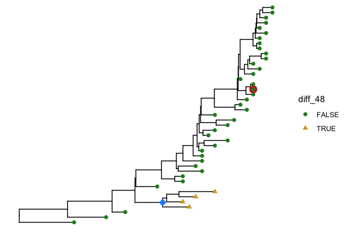

```r
# regenerate clean version of tree_dat
tree_dat <- fortify(tree)

# merge output from generate_branch_vars() with tree_dat
dat <- generate_branch_vars(tree_dat, variable_type = 'difference')

# subset this df do that only one virus is present as 'label_1' then
# left_join() using 'label_2'
taxa_subset <- subset(dat, label_1 == 'H1N1_A_FUKUSHIMA_141_2006')
tree_dat <- left_join(tree_dat, taxa_subset, by = c('label' = 'label_2'))

ggtree(tree) +
  # Viewpoint virus highlighted in red tip node
  geom_point(data = subset(tree_dat,
                           label == 'H1N1_A_FUKUSHIMA_141_2006'),
             col = 'firebrick3', size = 4) +
  # branch/node assoc. variable diff_48 highlighted with blue diamond
  geom_point(data = subset(tree_dat, node == 48),
             col = 'dodgerblue', shape = 18, size = 4) +
  # colour/shape of tip nodes depend on whether the combination of them and
  # the viewpoint virus are separated by the branch
  geom_point(data = subset(tree_dat, isTip == TRUE),
             aes(col = diff_48, shape = diff_48), size = 2) +
  scale_color_manual(values = c('forestgreen', 'goldenrod'))
```

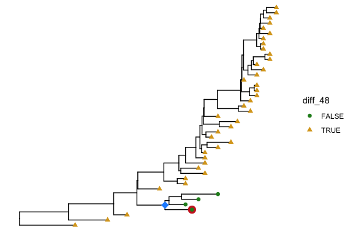

```r
# regenerate clean version of tree_dat
tree_dat <- fortify(tree)

# subset the df produced by generate_branch_vars again using a different virus
taxa_subset <- subset(dat, label_1 == 'H1N1_A_JOHANNESBURG_82_1996')
tree_dat <- left_join(tree_dat, taxa_subset, by = c('label' = 'label_2'))

ggtree(tree) +
  # Viewpoint virus highlighted in red tip node
  geom_point(data = subset(tree_dat,
                           label == 'H1N1_A_JOHANNESBURG_82_1996'),
             col = 'firebrick3', size = 4) +
  # branch/node assoc. variable diff_48 highlighted with blue diamond
  geom_point(data = subset(tree_dat, node == 48),
             col = 'dodgerblue', shape = 18, size = 4) +
  # colour/shape of tip nodes depend on whether the combination of them and
  # the viewpoint virus are separated by the branch
  geom_point(data = subset(tree_dat, isTip == TRUE),
             aes(col = diff_48, shape = diff_48), size = 2) +
  scale_color_manual(values = c('forestgreen', 'goldenrod'))
```